# act_report

### Investigation Report

I would like to investigate the tweets from the WeRateDogs (Twitter account that rates people's dogs with a humorous comment). The dataframe includes information that are gatherd from different sources and then merged into on data frame named tweet_archive

### Explore Dataset- Questions

I would like to know if the success of a tweet in terms of amount of retweets and favorites is related to the rating from WeRateDogs (have higher rated dogs more retweets & get more favorites)

Furthermore, it would be interesting to investigagte if the creator of WeRateDogs rate a some breeds better than others. Can we see from the data if the owners have a favorite breed?

In contrast, do the user have rate a some breeds retweet and fovourite some breeds more than others. Can we see from the data if the owners have a favorite breed?

### 1. Further cleaning of the data frame to make it a better fit for my planed investigation

#### Since I wont need all columns for my investigation I will drop the following columns from the data frame:

- in_reply_to_status_id
- in_reply_to_user_id
- timestamp
- source
- expanded_urls
- doggo
- floofer
- pupper
- puppo

#### The first problem that I see is that we have not for every tweet the following values: breed, favorite_count , retweet_count.

- so I dropped the null values from the data set which I created by just including values >0

#### The second problem is to make the rating from WeRateDogs more comparable by dividing the rating_numerator by the rating_denominator since both have so many outliers

- I added a new column called rating_new which divides the numerator by the denominator

#### Outliers:

Even though the ratings have some outliers, I decided to keep the outliers since the rating system is what WeRateDogs so special

### Question 1. Do the creator of WeRateDogs rate a some breeds better than others. Can we see from the data if the owners have a favorite breed?

The finding shows that the creators of the Twitter Account WeRateDogs have their favorites when you look at the average rating of the different breeds. Maybe the creators have on of these breeds as pet and are therefore biased?

### Question 2. Do the user have rate a some breeds retweet and fovourite some breeds more than others. Can we see from the data if the owners have a favorite breed?

#### The findings show that the users and creators dont have exactly the same favorites but there are 2 breeds in the Top 10 rated list which have a lot of retweets and/or favorites:

- black-and-tan coonhound
- bouvier des flandres

its also interesting to see that the most of the top retweeted and faved breeds are not the same: the bedlington terrier is the most retweeted and the black-and-tan coonhound is the most faved breed. It would be interesting to further investigate when the user retweeted a tweet and when they faved a tweet.

#### All in all, it seems like the black-and-tan coonhound is the most popular breed among the creators of WeRateDogs (#2 of 10) and among the users (#1 of 10 in faved tweets and #3 of 10 in retweets)

### Question 3. I would like to know if the sucess of a tweet in terms of amount of retweets and favorites is related to the rating from WeRateDogs (have higher rated dogs more retweets & get more favorites)

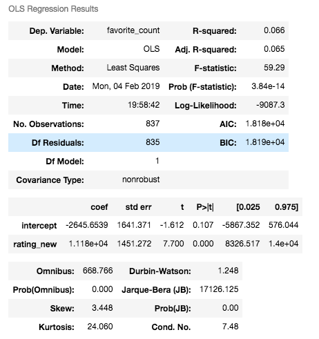

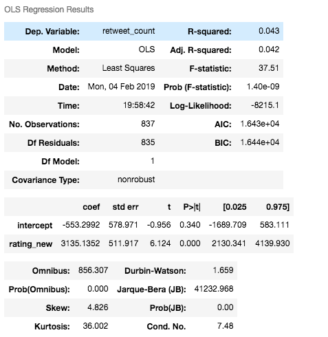

Even though we have statistical significant results, the the R-squared value are really low which indicates that our models doesnt fit the data really well (source:https://classroom.udacity.com/nanodegrees/nd002/parts/bb0cbeb6-d3f8-4bae-9dc3-4abba3823e54/modules/82c7c576-88f5-43b6-80fc-c53378527a2d/lessons/d780a3b0-a08e-4282-858e-6a28e8d524aa/concepts/f57165c9-d120-4277-b920-f427bbdb060b)

### Summary

The finding shows that the creators of the Twitter Account WeRateDogs have their favorites when you look at the average rating of the different breeds.

The findings also show that the users and creators dont have exactly the same favorites but there are 2 breeds in the Top 10 rated list which have a lot of retweets and/or favorites: `black-and-tan coonhound and bouvier des flandres`

I also found a statistically significant positive effect from WeRateDogs ratings on the number of retweets and favorites.